# Statystyka - Projekt

Mateusz Marczyk & Karol Sewiło

2023-01-26

## Wstęp

#### Celem projektu jest porównanie działania dwóch algorytmów minimalizacji stochastycznej. Do porównania wybraliśmy **algorytm poszukiwania przypadkowego (PRS)** oraz **algorytm genetyczny** (GA).

## Zmienne globalne

```r
budget <- 1000
cost <- 100
alfa <- 0.05
```

## Implementacje wybranych algorytmów

## [Algorytm Pure Random Search (PRS)](https://en.wikipedia.org/wiki/Random_search#Algorithm)

```r
PRS <- function(lower_bound, upper_bound, f,n) {
  if(length(lower_bound) !=  length(upper_bound)) stop("Bounds must be equal dimensions")

  p <- integer(length(lower_bound))
  fmin <- Inf

  for (x in 1:n) {
    for(i in seq_along(p)) {
      p[i] <- runif(1, lower_bound[i], upper_bound[i])
    }
    fmin <- min(fmin, f(p))
  }
  return(fmin)
}
```

## [Algorytm Genetyczny (GA)](https://pl.wikipedia.org/wiki/Algorytm_genetyczny)

```r
GA <- function(f, n){
result <- ga(
  type = "real-valued",
  fitness = function(x) (-1)*f(x),
  lower = getLowerBoxConstraints(f),
  upper = getUpperBoxConstraints(f),
  maxiter = 40,
  popSize = 25)

return(-result@fitnessValue)
}
```

## Funckja obliczania przedziału ufności

```r
CONF_INTRV <- function(vector, alfa)
  return(unname(c(mean(vector)-quantile(vector, 1-(alfa/2))*sd(vector)/sqrt(length(vector)), mean(vector)+quantile(vector, 1-(alfa/2))*sd(vector)/sqrt(length(vector)))))
```

## Wybrane funkcje

Do testów wybraliśmy funkcję **Akcley’a** oraz **Rastrigin’a**. Obie są skalarnem wielomodalne oraz akceptują dane w różnych wymiarach.

## Opracowanie danych

Na początu analizować będziemy wyniki obu algorytmów dla funkcji Akcley’a w odpowiednio: 2, 10 oraz 20 wymiarach. Następnie przeprowdzimy analogiczną analizę dla funkcji Rastrigin’a.

## Hipoteza zerowa

- Algorytmy nie różnią się efektywnością szukania minimum funkcji.

## Hipotezy alternatywne

1. Algorytm PRS jest efektywniejszy w szukaniu minimum funkcji.

2. Algorytm genetyczny jest efektywniejszy w szukaniu minimum funkcji.

# [Funkcja Ackley’a](https://www.sfu.ca/~ssurjano/ackley.html)

#### Wzór funkcji:

$f\left( \textbf{x} \right)=-a \cdot \exp\left(-b\sqrt{\frac{1}{d}\sum_{i=1}^{d}x_{i}^{2}}) \right)-\exp\left( \frac{1}{d}\sum_{i=1}^{d}\cos\left( cx_{i} \right) \right) + a + \exp\left( 1 \right)$

#### Minimum globalne:

$f \left( \textbf{x}^{*} \right)=0,\ \ \text{at } \textbf{x}^{*}=\left( 0,..,0 \right)$

#### Zalecana dziedzina poszukiwań:

$x_{i} \in \left[ -32.768,\ \ 32.768 \right], \ \ \forall_{1\le i\le d}, \ \text{gdzie } d \text{ to wymiar przestrzeni}$

#### Domyślne stałe:

$a=20, \ \ b=0.2, \ \ c=2\pi$

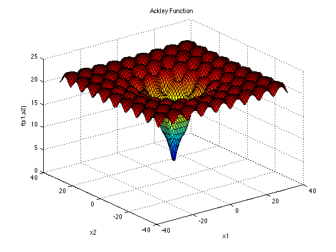

## 2 wymiary

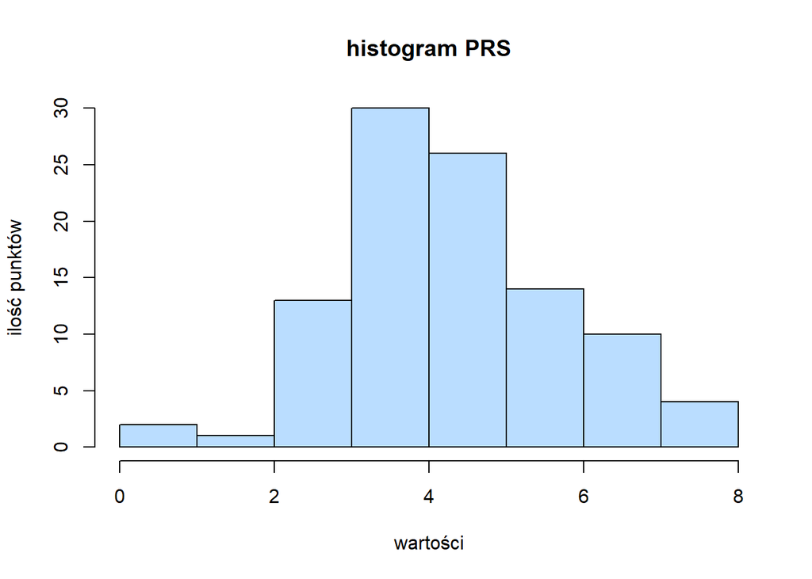

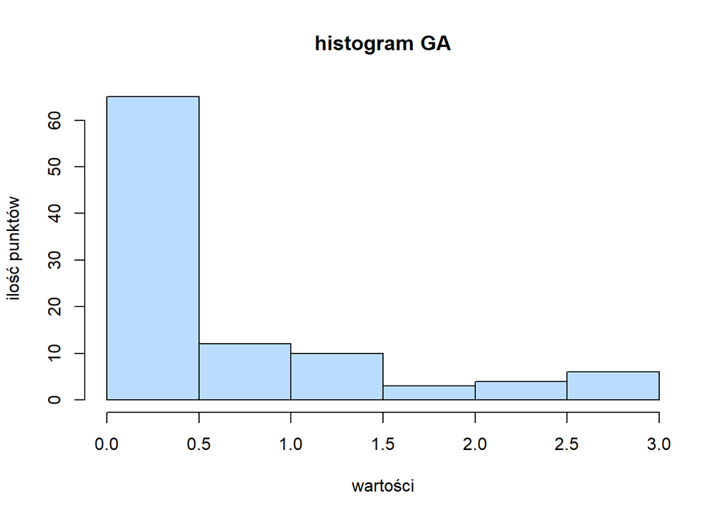

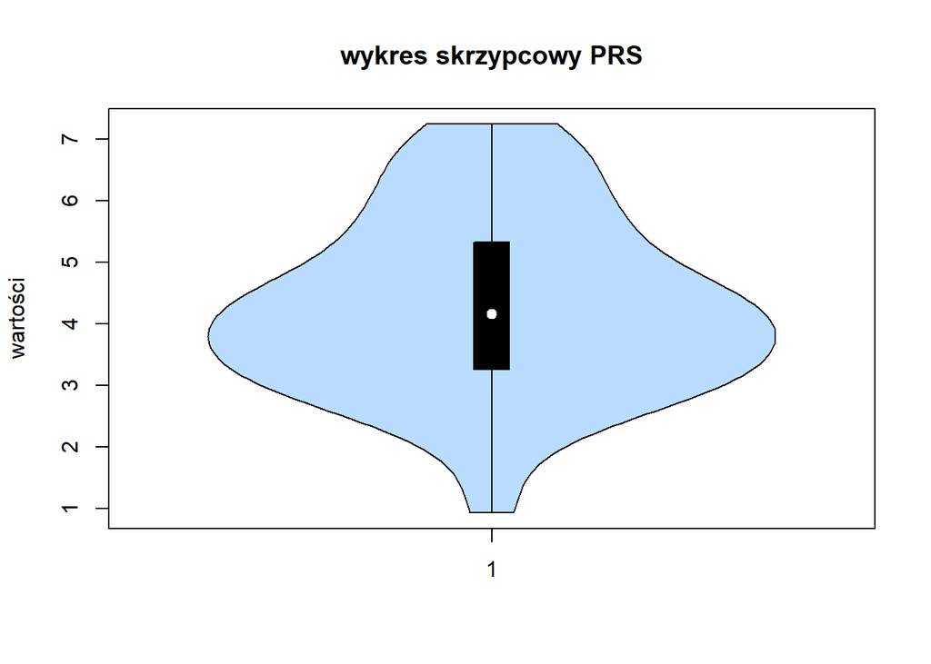

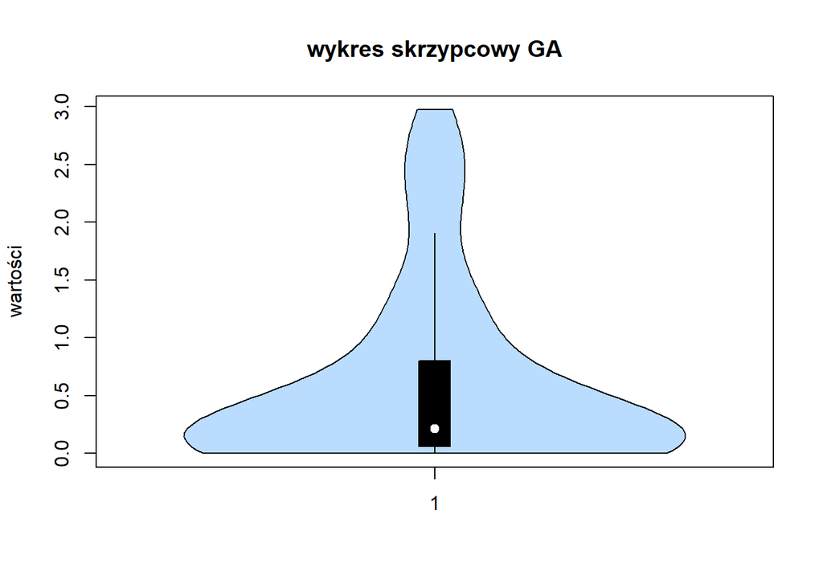

| Algorytm | średnia | mediana | odchylenie standardowe | wariancja |
| --- | --- | --- | --- | --- |
| Prs | 4.275382 | 4.154472 | 1.420923 | 2.019022 |
| Ga | 0.5836287 | 0.2127156 | 0.7853937 | 0.6168433 |

```r
  ackley <- makeAckleyFunction(2)

  a_prs <- replicate(n = cost,
                 PRS(getLowerBoxConstraints(ackley),
                     getUpperBoxConstraints(ackley),
                     ackley,
                     budget))
  a_ga <- replicate(n = cost, GA(ackley, budget))
  hist(a_prs, main="histogram PRS", xlab = "wartości", ylab = "ilość punktów", col = "#BADDFF")
  hist(a_ga, main="histogram GA", xlab = "wartości", ylab = "ilość punktów", col = "#BADDFF")
  vioplot(a_prs, main="wykres skrzypcowy PRS", ylab = "wartości", col = "#BADDFF")
  vioplot(a_ga, main="wykres skrzypcowy GA", ylab = "wartości", col = "#BADDFF")
```

## Podsumowanie

Obliczamy przedziały ufności:

##### **PRS**

```r
conf_interval <- CONF_INTRV(a_prs, alfa)
conf_interval
```

```
## [1] 3.274548 5.276216
```

##### **GA**

```r
conf_interval <- CONF_INTRV(a_ga, alfa)
conf_interval
```

```
## [1] 0.3756612 0.7915962
```

W przypadku porównywania 2 wymiarów dla funkcji Ackley’a sprawdza się hipoteza alternatywna 2. Dla algorytmu PRS średnia jest bardzo zbliżona do mediany, a odchylenie standardowe jest niewielkie. Natomiast dla algorytmu genetycznego średnia jest niemal trzykrotnie większa od mediany, a odchylenie standardowe jest znaczące.

## 10 wymiarów

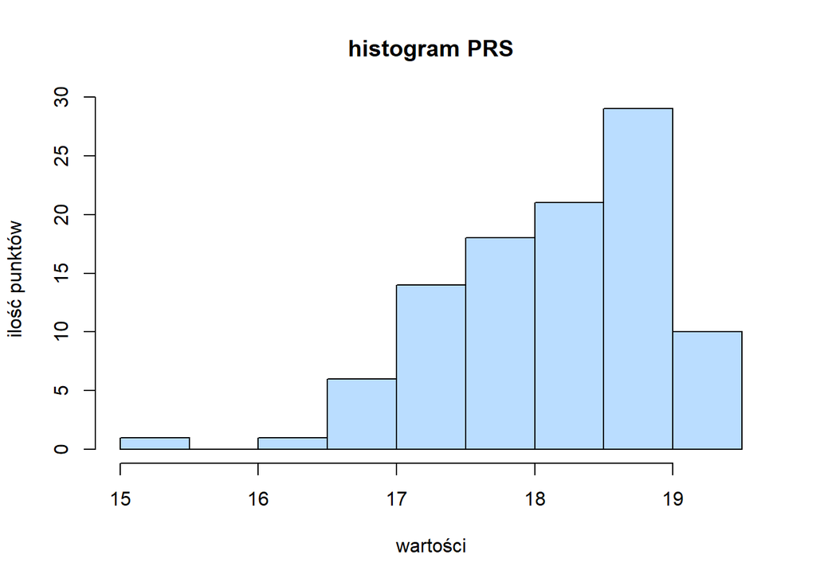

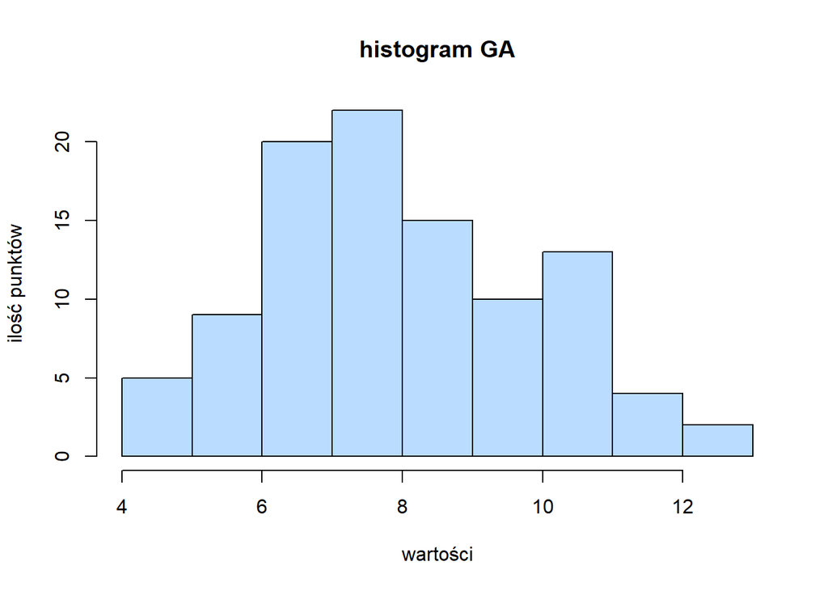

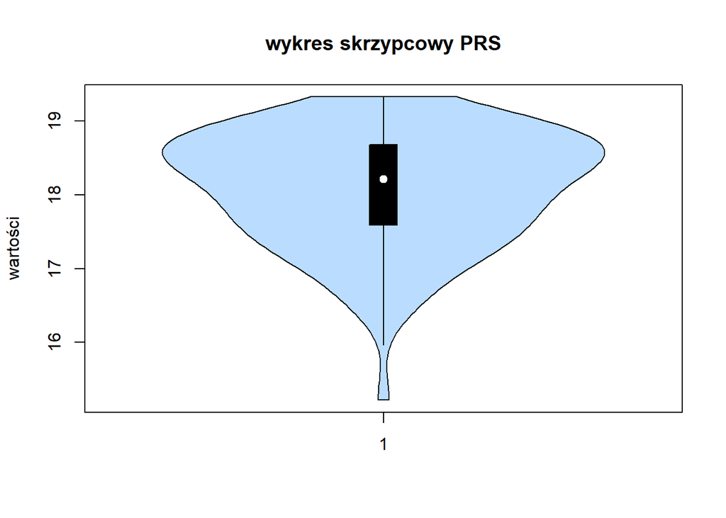

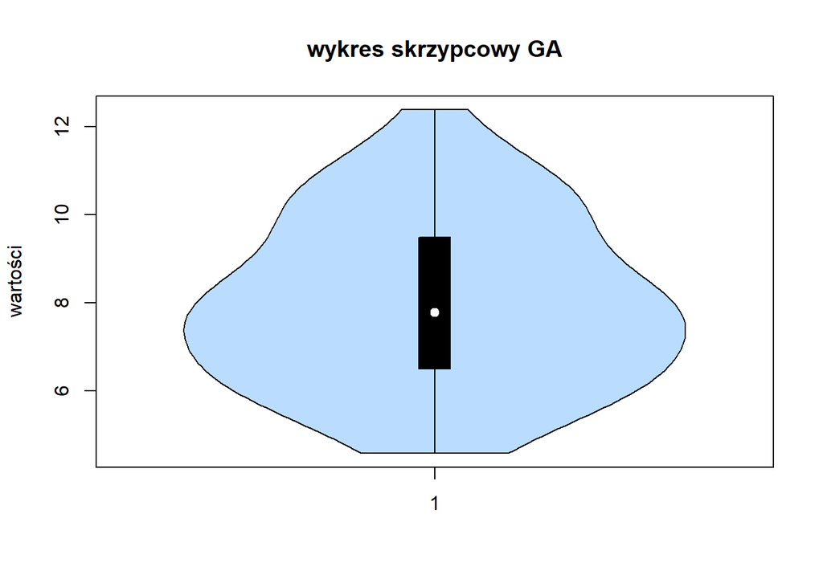

| Algorytm | średnia | mediana | odchylenie standardowe | wariancja |
| --- | --- | --- | --- | --- |
| Prs | 18.0935143 | 18.2096402 | 0.7707545 | 0.5940626 |
| Ga | 7.991149 | 7.778349 | 1.900478 | 3.611818 |

```r
  ackley <- makeAckleyFunction(10)

  a_prs <- replicate(n = cost,
                 PRS(getLowerBoxConstraints(ackley),
                     getUpperBoxConstraints(ackley),
                     ackley,
                     budget))
  a_ga <- replicate(n = cost, GA(ackley, budget))
  hist(a_prs, main="histogram PRS", xlab = "wartości", ylab = "ilość punktów", col = "#BADDFF")
  hist(a_ga, main="histogram GA", xlab = "wartości", ylab = "ilość punktów", col = "#BADDFF")
  vioplot(a_prs, main="wykres skrzypcowy PRS", ylab = "wartości", col = "#BADDFF")
  vioplot(a_ga, main="wykres skrzypcowy GA", ylab = "wartości", col = "#BADDFF")
```

## Podsumowanie

Obliczamy przedziały ufności:

##### **PRS**

```r
conf_interval <- CONF_INTRV(a_prs, alfa)
conf_interval
```

```
## [1] 16.62230 19.56473
```

##### **GA**

```r
conf_interval <- CONF_INTRV(a_ga, alfa)
conf_interval
```

```
## [1]  5.796658 10.185640
```

W przypadku porównywania 10 wymiarów dla funkcji Ackley’a sprawdza się hipoteza alternatywna 2. Dla algorytmu PRS średnia jest bardzo zbliżona do mediany, a odchylenie standardowe jest niewielkie. Dla algorytmu genetycznego średnia jest podobna do mediany, a odchylenie standardowe nie jest znaczące.

## 20 wymiarów

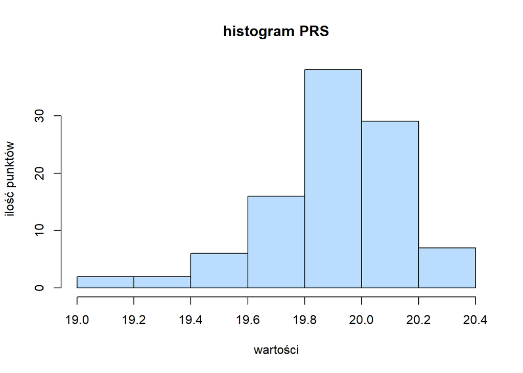

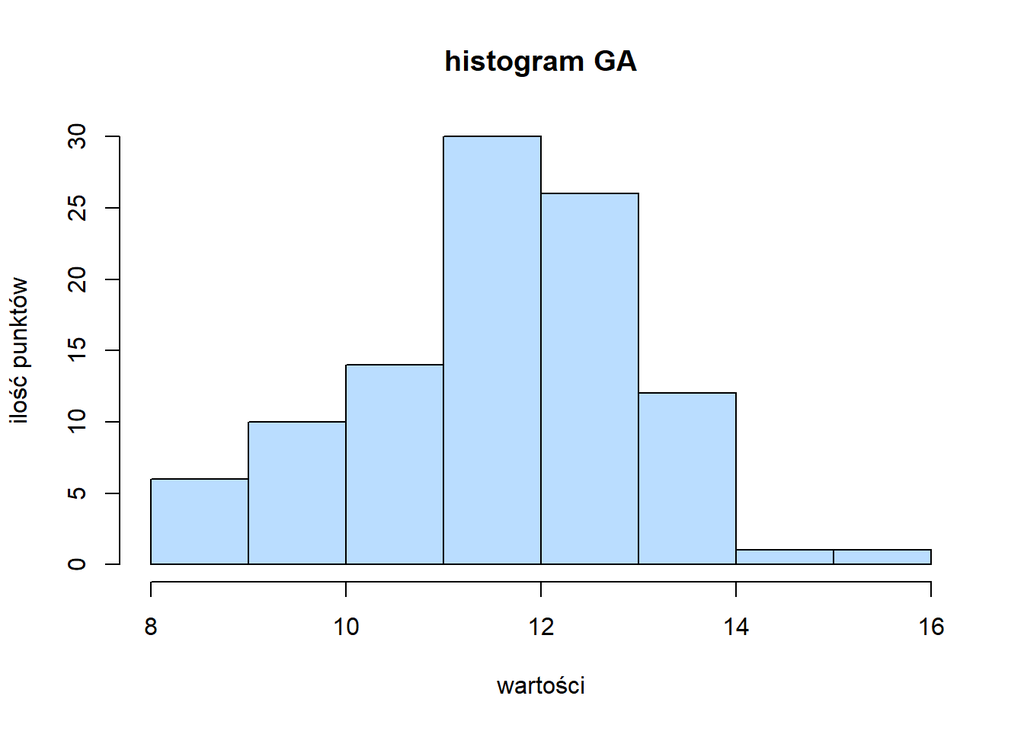

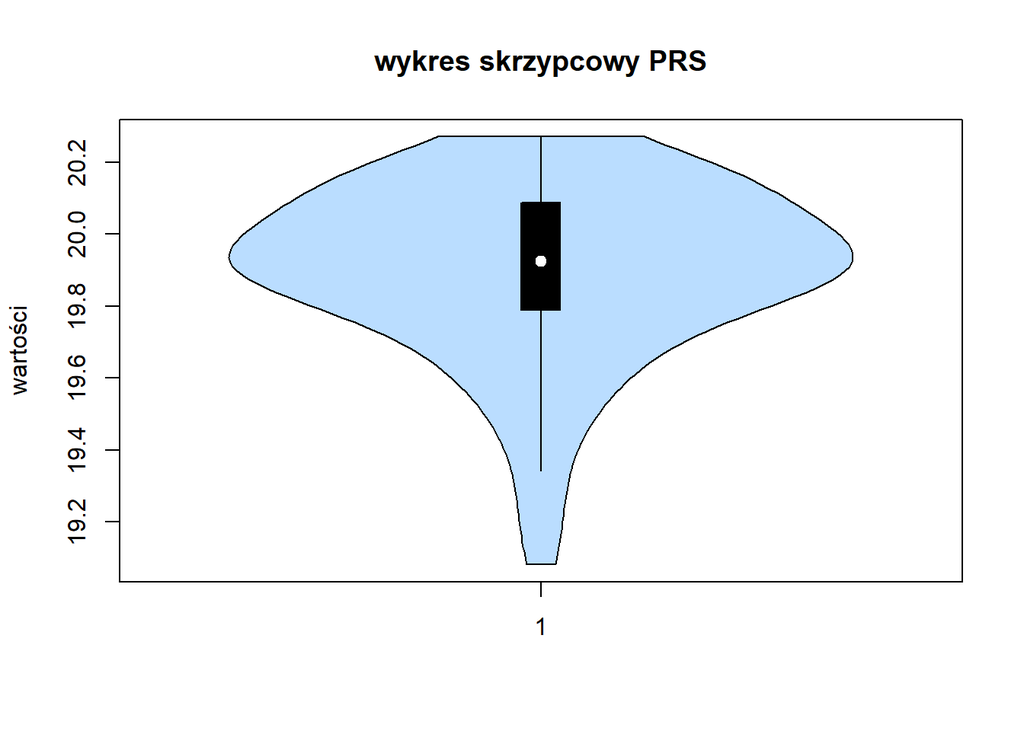

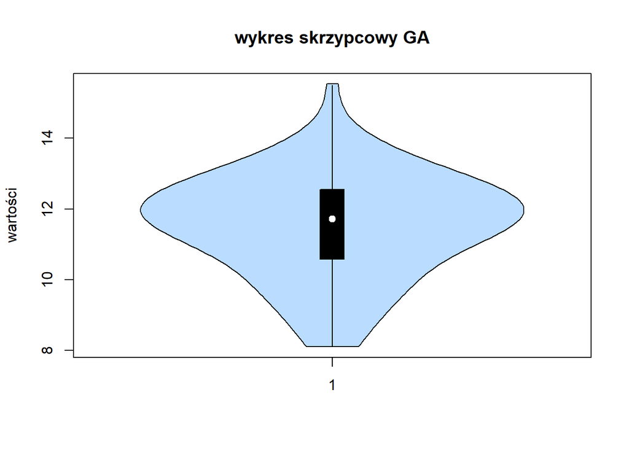

| Algorytm | średnia | mediana | odchylenie standardowe | wariancja |
| --- | --- | --- | --- | --- |
| Prs | 19.90033605 | 19.92528026 | 0.24156182 | 0.05835211 |
| Ga | 11.549499 | 11.712324 | 1.454063 | 2.114299 |

```r
  ackley <- makeAckleyFunction(20)

  a_prs <- replicate(n = cost,
                 PRS(getLowerBoxConstraints(ackley),
                     getUpperBoxConstraints(ackley),
                     ackley,
                     budget))
  a_ga <- replicate(n = cost, GA(ackley, budget))
  hist(a_prs, main="histogram PRS", xlab = "wartości", ylab = "ilość punktów", col = "#BADDFF")
  hist(a_ga, main="histogram GA", xlab = "wartości", ylab = "ilość punktów", col = "#BADDFF")
  vioplot(a_prs, main="wykres skrzypcowy PRS", ylab = "wartości", col = "#BADDFF")
  vioplot(a_ga, main="wykres skrzypcowy GA", ylab = "wartości", col = "#BADDFF")
```

## Podsumowanie

Obliczamy przedziały ufności:

##### **PRS**

```r
conf_interval <- CONF_INTRV(a_prs, alfa)
conf_interval
```

```
## [1] 19.41127 20.38940
```

##### **GA**

```r
conf_interval <- CONF_INTRV(a_ga, alfa)
conf_interval
```

```
## [1]  9.519652 13.579346
```

W przypadku porównywania 20 wymiarów dla funkcji Ackley’a sprawdza się hipoteza alternatywna 2. Dla algorytmu PRS średnia jest prawie identyczna jak mediana, a odchylenie standardowe jest bardze małe. Dla algorytmu genetycznego średnia jest bardzo zbliżona do mediany, a odchylenie standardowe jest stosunkowo niewielkie.

# [Funkcja Rastrigin’a](https://www.sfu.ca/~ssurjano/rastr.html)

#### Wzór funkcji:

$f\left( \textbf{x} \right)=10d + \sum_{i=1}^{d}\left( x^{2}_{i} -10\cos(2\pi x_{i})\right)$

#### Minimum globalne:

$f \left( \textbf{x}^{*} \right)=0,\ \ \text{at } \textbf{x}^{*}=\left( 0,..,0 \right)$

#### Zalecana dziedzina poszukiwań:

$x_{i} \in \left[ -5.12,\ \ 5.12 \right], \ \ \forall_{1\le i\le d}, \ \text{gdzie } d \text{ to wymiar przestrzeni}$

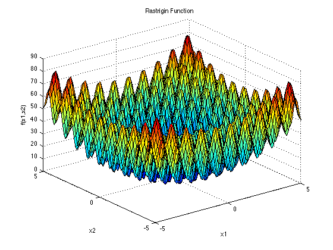

## 2 wymiary

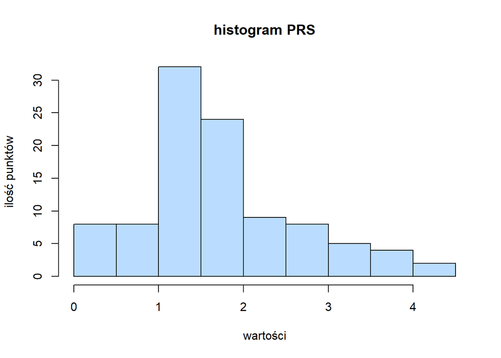

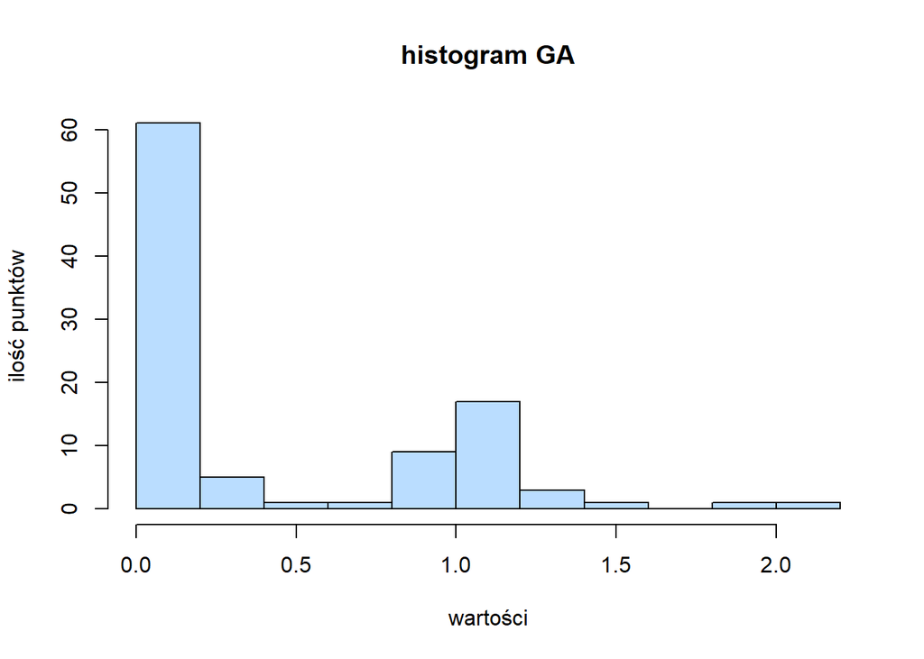

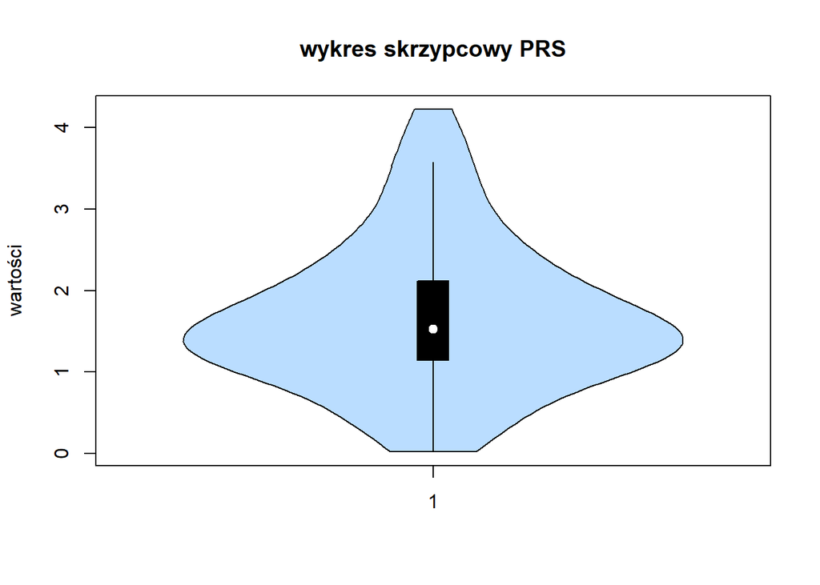

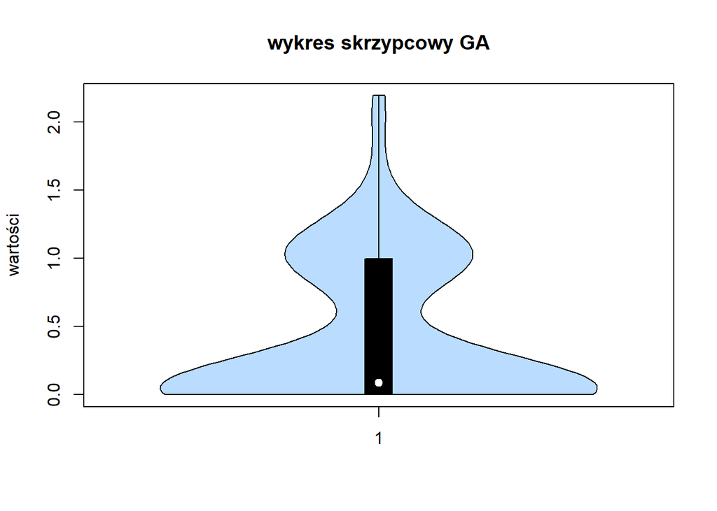

| Algorytm | średnia | mediana | odchylenie standardowe | wariancja |
| --- | --- | --- | --- | --- |
| Prs | 1.6849430 | 1.5276102 | 0.8991705 | 0.8085075 |
| Ga | 0.41478896 | 0.08661706 | 0.53380372 | 0.28494641 |

```r
  rastrigin <- makeRastriginFunction(2)

  r_prs <- replicate(n = cost,
                 PRS(getLowerBoxConstraints(rastrigin),
                     getUpperBoxConstraints(rastrigin),
                     rastrigin,
                     budget))
  r_ga <- replicate(n = cost, GA(rastrigin, budget))
  hist(r_prs, main="histogram PRS", xlab = "wartości", ylab = "ilość punktów", col = "#BADDFF")
  hist(r_ga, main="histogram GA", xlab = "wartości", ylab = "ilość punktów", col = "#BADDFF")
  vioplot(r_prs, main="wykres skrzypcowy PRS", ylab = "wartości", col = "#BADDFF")
  vioplot(r_ga, main="wykres skrzypcowy GA", ylab = "wartości", col = "#BADDFF")
```

## Podsumowanie

Obliczamy przedziały ufności:

##### **PRS**

```r
conf_interval <- CONF_INTRV(a_prs, alfa)
conf_interval
```

[output not shown]

##### **GA**

```r
conf_interval <- CONF_INTRV(a_ga, alfa)
conf_interval
```

[output not shown]

## 10 wymiarów

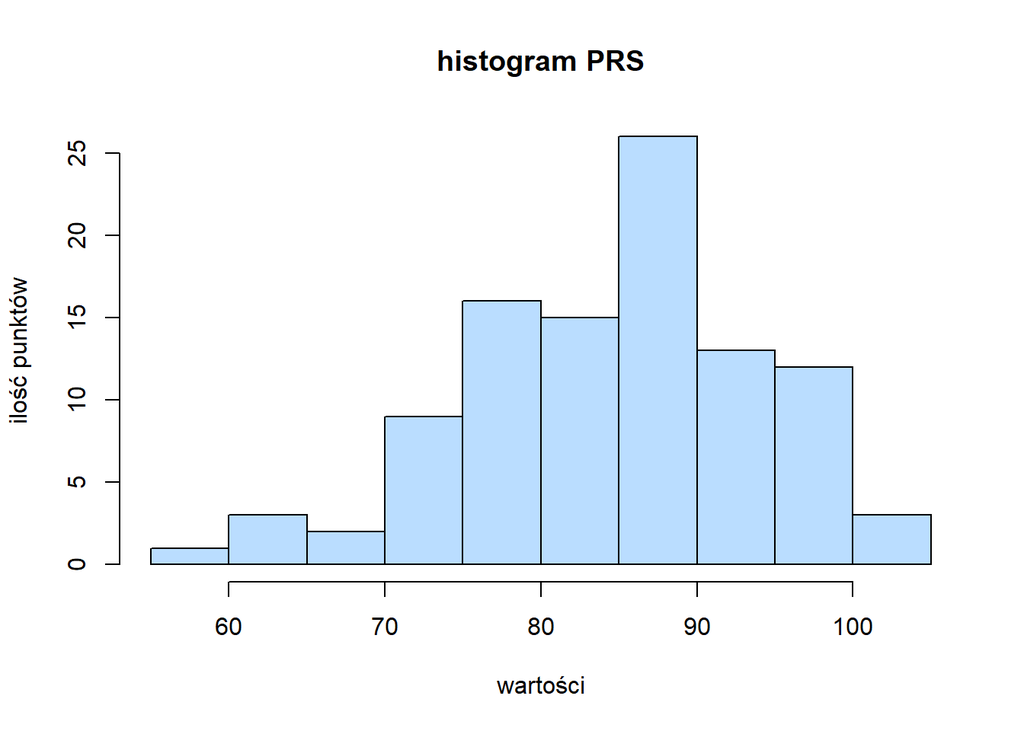

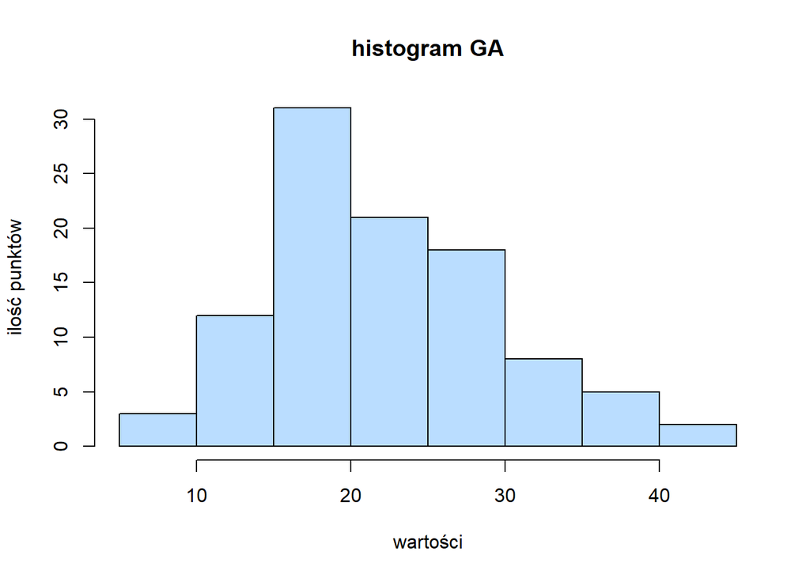

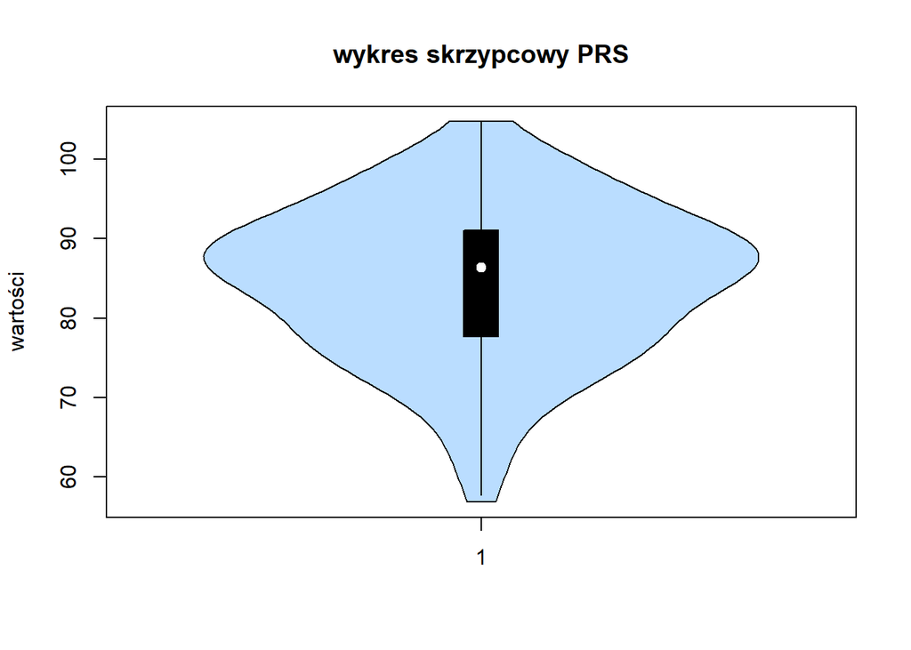

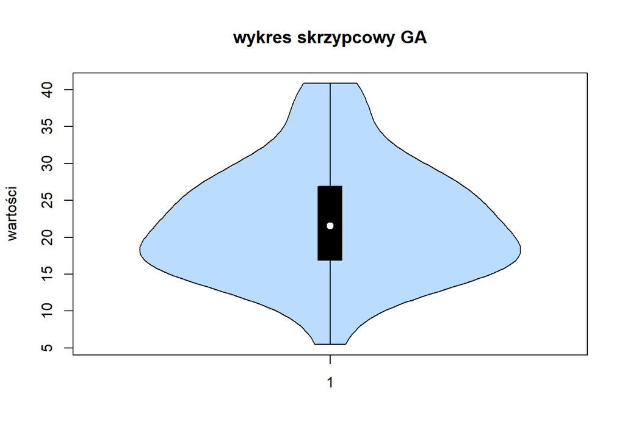

| Algorytm | średnia | mediana | odchylenie standardowe | wariancja |
| --- | --- | --- | --- | --- |
| Prs | 84.674428 | 86.327949 | 9.533503 | 90.887679 |
| Ga | 22.178742 | 21.533745 | 7.570933 | 57.319031 |

```r
  rastrigin <- makeRastriginFunction(10)

  r_prs <- replicate(n = cost,
                 PRS(getLowerBoxConstraints(rastrigin),
                     getUpperBoxConstraints(rastrigin),
                     rastrigin,
                     budget))
  r_ga <- replicate(n = cost, GA(rastrigin, budget))
  hist(r_prs, main="histogram PRS", xlab = "wartości", ylab = "ilość punktów", col = "#BADDFF")
  hist(r_ga, main="histogram GA", xlab = "wartości", ylab = "ilość punktów", col = "#BADDFF")
  vioplot(r_prs, main="wykres skrzypcowy PRS", ylab = "wartości", col = "#BADDFF")
  vioplot(r_ga, main="wykres skrzypcowy GA", ylab = "wartości", col = "#BADDFF")
```

## Podsumowanie

Obliczamy przedziały ufności:

##### **PRS**

```r
conf_interval <- CONF_INTRV(a_prs, alfa)
conf_interval
```

[output not shown]

##### **GA**

```r
conf_interval <- CONF_INTRV(a_ga, alfa)
conf_interval
```

[output not shown]

## 20 wymiarów

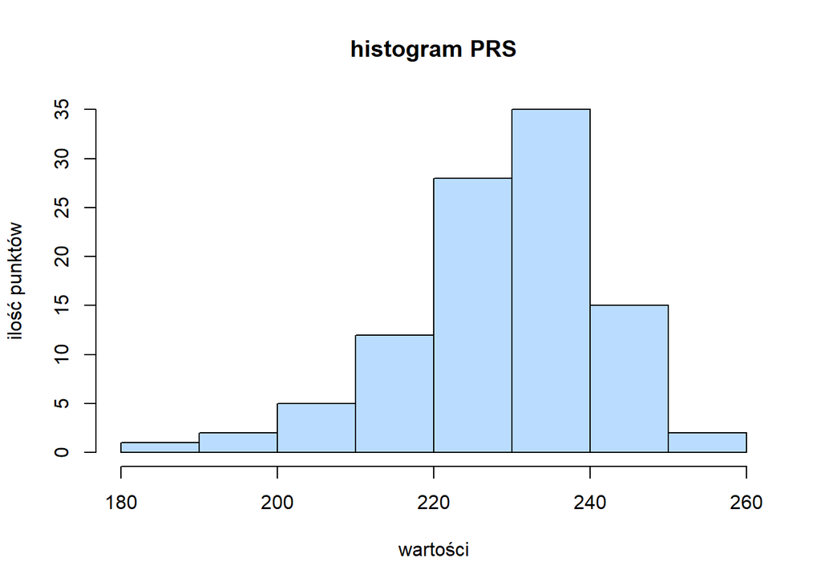

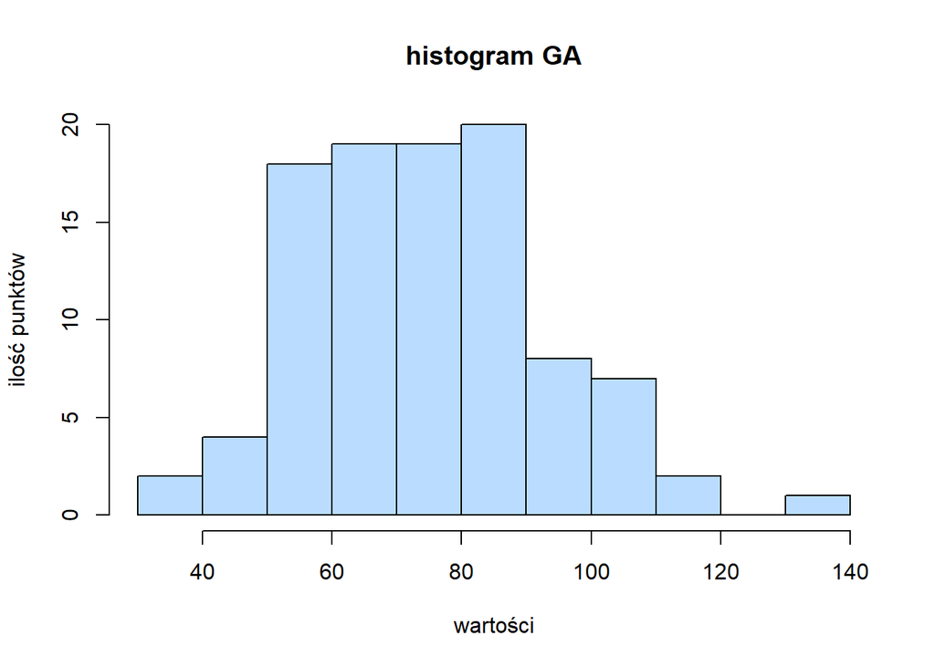

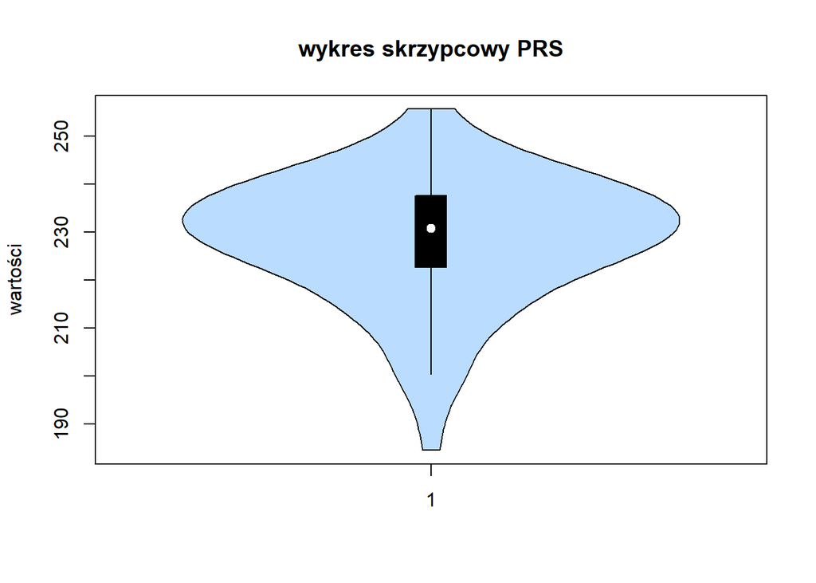

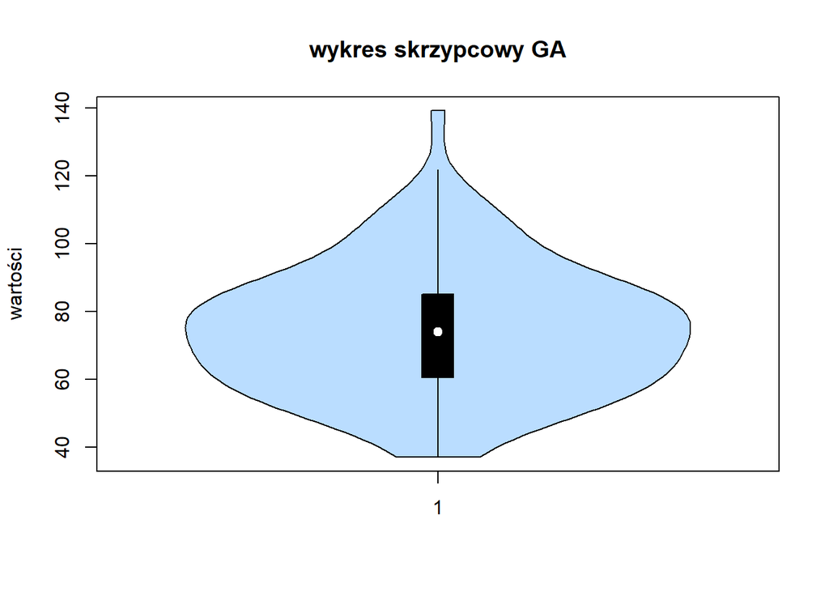

| Algorytm | średnia | mediana | odchylenie standardowe | wariancja |
| --- | --- | --- | --- | --- |
| Prs | 228.4766 | 230.6898 | 13.2615 | 175.8673 |
| Ga | 74.55114 | 74.01480 | 18.86128 | 355.74783 |

```r
  rastrigin <- makeRastriginFunction(20)

  r_prs <- replicate(n = cost,
                 PRS(getLowerBoxConstraints(rastrigin),
                     getUpperBoxConstraints(rastrigin),
                     rastrigin,
                     budget))
  r_ga <- replicate(n = cost, GA(rastrigin, budget))
  hist(r_prs, main="histogram PRS", xlab = "wartości", ylab = "ilość punktów", col = "#BADDFF")
  hist(r_ga, main="histogram GA", xlab = "wartości", ylab = "ilość punktów", col = "#BADDFF")
  vioplot(r_prs, main="wykres skrzypcowy PRS", ylab = "wartości", col = "#BADDFF")
  vioplot(r_ga, main="wykres skrzypcowy GA", ylab = "wartości", col = "#BADDFF")
```

## Podsumowanie

Obliczamy przedziały ufności:

##### **PRS**

```r
conf_interval <- CONF_INTRV(a_prs, alfa)
conf_interval
```

[output not shown]

##### **GA**

```r
conf_interval <- CONF_INTRV(a_ga, alfa)
conf_interval
```

[output not shown]

W przypadku porównywania 20 wymiarów dla funkcji Rastrigin’a sprawdza się hipoteza alternatywna 2. Dla algorytmu PRS średnia jest bardzo bliska medianie, a odchylenie standardowe jest bardzo niewielkie. Natomiast dla algorytmu genetycznego średnia praktycznie pokrywa się z miedaną, a odchylenie standardowe jest znaczące.